# ESADA

Christos Nikolaidis

11/01/2020

#### Dataset view

Install the latest version of the `foreign` package: `install.packages("foreign")`

```r
library(foreign)
```

*Converitng file format (.sav to .csv)

```r
write.table(read.spss("ESADA.sav"), file="ESADA.csv", col.names = TRUE,
            row.names = FALSE, sep = ",")
library(readr)
```

*Reading the file

```r
ESADA <-read_csv("ESADA.csv")
```

*How many unique sites?*

```r
unique(ESADA$Site)
```

```
##  [1] "Prague"
##  [2] "Brno"
##  [3] "Klecany"
##  [4] "Thessaloniki"
##  [5] "Alexandroupolis"
##  [6] "Crete"
##  [7] "Athens"
##  [8] "Brussels"
##  [9] "Antwerp"
## [10] "Paris"
## [11] "Grenoble"
## [12] "Barcelona"
## [13] "Lleida"
## [14] "Cãceres"
## [15] "Turku"
```

[output cut: 21 more lines]

*Correcting language issue

```r
Sys.setlocale(category = "LC_CTYPE", locale = "en_US.UTF-8")
```

```
## [1] "en_US.UTF-8"
```

#### Cleaning the data

*Install the latest version of the `tidyverse` package: `install.packages("tidyverse")`

```r
library(tidyverse)
```

```r
which(is.na(ESADA$Site))
```

```
## [1] 8415
```

*In row #8415 there is a missing value

*Search for “Site” name elsewhere in the dataset

```r
names(select(ESADA, contains("Site")))
```

```
## [1] "Site"   "F1Site" "F2Site" "F3Site" "F4Site" "F5Site"
```

```r
grep("*Site$", colnames(ESADA) )
```

```
## [1]    1  216  460  705  947 1187
```

*Check other Site names*

```r
ESADA[8415, c(1,216,460,705,947,1187)]
```

```
## # A tibble: 1 x 6
##   Site  F1Site F2Site F3Site F4Site F5Site
##   <chr> <chr>  <chr>  <chr>  <chr>  <chr>
## 1 <NA>  Split  <NA>   <NA>   <NA>   <NA>
```

*Recode missing #8415*

```r
ESADA$Site[is.na(ESADA$Site)] <- "Split"
```

*Create new variable “Country”*

```r
ESADA$Country <- ifelse(ESADA$Site %in% c("Prague", "Brno", "Klecany"), "Czech Republic",
ifelse(ESADA$Site %in% c("Thessaloniki", "Alexandroupolis", "Crete", "Athens"), "Greece",
ifelse(ESADA$Site %in% c("Brussels", "Antwerp"), "Belgium",
ifelse(ESADA$Site %in% c("Paris", "Grenoble"), "France",
ifelse(ESADA$Site %in% c("Barcelona", "Lleida", "Cãceres"), "Spain",
ifelse(ESADA$Site=="Turku", "Finland",
ifelse(ESADA$Site=="Riga", "Latvia",
ifelse(ESADA$Site=="Split", "Croatia",
ifelse(ESADA$Site %in% c("Palermo", "Milano"), "Italy",
ifelse(ESADA$Site=="Kosice", "Slovakia",
ifelse(ESADA$Site=="Edinburgh", "Scotland",
ifelse(ESADA$Site=="Gothenburg", "Sweden",
ifelse(ESADA$Site=="Førde", "Norway",
ifelse(ESADA$Site %in% c("Warsaw Medical University",
                         "Warsaw Institute of Tuberculosis and Lung Diseases"), "Poland",
ifelse(ESADA$Site %in% c("Berlin", "Giessen", "Hamburg", "Mainz"), "Germany",
ifelse(ESADA$Site %in% c("Lisbon", "Porto"), "Portugal",
ifelse(ESADA$Site=="Dublin", "Ireland",
ifelse(ESADA$Site=="Klaipeda", "Lithuania",
ifelse(ESADA$Site=="Izmir", "Turkey",
ifelse(ESADA$Site=="Haifa", "Israel", NA))))))))))))))))))))
```

*Move “Country” next to “Site”

```r
ESADA <- ESADA %>% select(Site, Country, everything())
```

*Number of countries*

```r
unique(ESADA$Country)
```

```
##  [1] "Czech Republic" "Greece"         "Belgium"        "France"
##  [5] "Spain"          "Finland"        "Latvia"         "Croatia"
##  [9] "Italy"          "Slovakia"       "Scotland"       "Sweden"
## [13] "Norway"         "Poland"         "Germany"        "Portugal"
## [17] "Ireland"        "Lithuania"      "Turkey"         "Israel"
```

*Data entries per country*

```r
table(ESADA$Country)
```

```
##
##        Belgium        Croatia Czech Republic        Finland         France
##           1280           1612           1074           1067           1229
##        Germany         Greece        Ireland         Israel          Italy
##           1100           2084           1628            580           1109
##         Latvia      Lithuania         Norway         Poland       Portugal
##             18            700           2078           2938            272
##       Scotland       Slovakia          Spain         Sweden         Turkey
##            316            937            580           2487           2410
```

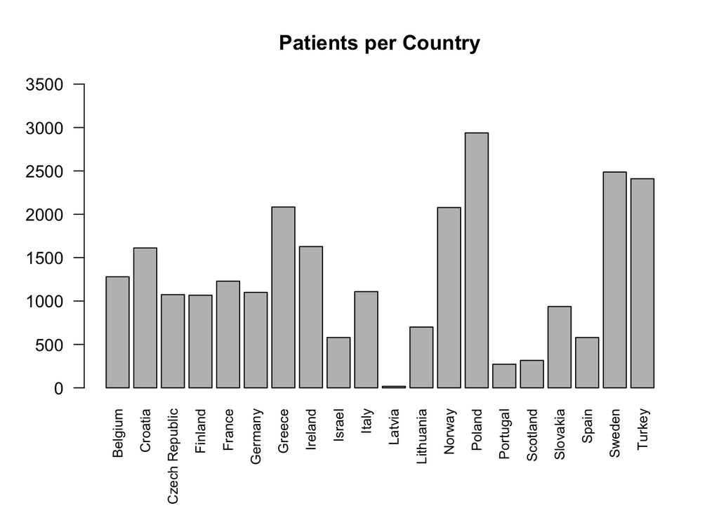

```r
by_country <- ESADA %>%
    group_by(Country) %>%
    summarise(counts = n())
par(mar=c(6.1,4.1,4.1,2.1))
barplot(by_country$counts, name=by_country$Country,
        cex.names = 0.8, ylim= c(0,3500), las=2, main="Patients per Country")
```

*Create a subset of the data*

```r
Data1 <- ESADA[c(1:215)]
write.csv(Data1, file = "Data1.csv")
```

*Looking at the file*

```r
str(Data1)
```

```
## Classes 'tbl_df', 'tbl' and 'data.frame':    25499 obs. of  215 variables:
##  $ Site                                       : chr  "Prague" "Prague" "Prague" "Prague" ...
##  $ Country                                    : chr  "Czech Republic" "Czech Republic" "Czech Republic" "Czech Republic" ...
##  $ PatientID                                  : num  2e+07 2e+07 2e+07 2e+07 2e+07 ...
##  $ VisitDate                                  : num  1.34e+10 1.34e+10 1.34e+10 1.34e+10 1.34e+10 ...
##  $ Year                                       : num  2008 2008 2008 2008 2008 ...
##  $ Gender                                     : chr  "Male" "Male" "Male" "Male" ...
##  $ Race                                       : chr  "Caucasian" "Caucasian" "Caucasian" "Caucasian" ...
##  $ Age                                        : num  63 36 39 46 33 54 55 59 53 42 ...
##  $ Height                                     : num  178 178 175 175 177 173 170 192 176 175 ...
##  $ Weight                                     : num  80 85 98 90 90 72 100 130 93 95 ...
##  $ BMI                                        : num  25.2 26.8 32 29.4 28.7 ...
##  $ SystolicBloodPressure                      : num  135 135 194 130 150 180 140 150 130 120 ...
##  $ MeanBloodPressure                          : num  98.3 95 127.3 96.7 106.7 ...
##  $ DiastolicBloodPressure                     : num  80 75 94 80 85 100 110 100 70 80 ...
```

[output cut: 92 more lines]

*Exploring variable names*

```r
names(Data1)
```

*Generates 215 variables (working DATASET)

*Checking for duplicates*

```r
sum(duplicated(Data1$PatientID))
```

```
## [1] 0
```

*Some summary statistics*

```r
table(Data1$Gender)
```

```
##
## Female   Male
##   7594  17904
```

```r
summary(Data1$Age)
```

```
##    Min. 1st Qu.  Median    Mean 3rd Qu.    Max.    NA's
##   18.00   44.00   54.00   52.71   62.00   94.00      11
```

```r
summary(Data1$BMI)
```

```
##    Min. 1st Qu.  Median    Mean 3rd Qu.    Max.    NA's
##    0.00   26.96   30.47   31.52   34.95   86.86     233
```

*Correcting “BMI” error by removing “0” values*par()

```r
Data1$BMI[is.na(Data1$BMI) | Data1$BMI==0] <- NA
```

```r
summary(Data1$MeanBloodPressure)
```

```
##    Min. 1st Qu.  Median    Mean 3rd Qu.    Max.    NA's
##   55.67   91.00   98.33   99.02  106.67  160.33    1279
```

```r
summary(Data1$HeartRate)
```

```
##    Min. 1st Qu.  Median    Mean 3rd Qu.    Max.    NA's
##   32.00   64.00   72.00   73.47   80.00  134.00    4287
```

```r
summary(Data1$WHR)
```

```
##    Min. 1st Qu.  Median    Mean 3rd Qu.    Max.    NA's
##  0.5773  0.9216  0.9792  0.9753  1.0300  1.5495    2533
```

### Grouping co-morbidities

*CVD*

```r
Data1$CVD <- ifelse(Data1$"CVSystemicHypertension"==1 |
                      Data1$"CVIschemicHeartDisease"==1 |
                      Data1$"CVLeftVentricularHypertrophy"==1 |
                      Data1$"CVValvularHeartDisease"==1 |
                      Data1$"CVTIAorstroke"==1|"AtrialFibrillation"==1 |
                      Data1$"CVPulmonaryHypertension"==1 |
                      Data1$"CVStatusPostMyocardialInfarction"==1 |
                      Data1$"CVCardiacfailure"==1 |
                      Data1$"CVOtherCerebrovascularDisease"==1 |
                      Data1$"CVOtherYesNo"==1, 1, 0)
```

*Metabolic*

```r
Data1$Metabolic <- ifelse(Data1$"MetabolicDiabetesNoninsulindependent"==1 |
                            Data1$"MetabolicDiabetesInsulinDependent"==1 |
                            Data1$"MetabolicHyperlipidemia"==1 |
                            Data1$"MetabolicHyperuricemia"==1 |
                            Data1$"MetabolicOtherYesNo"==1, 1, 0)
```

*Sleep*

```r
Data1$Sleep <- ifelse(Data1$"SleepDisorderOSA"==1 |
                        Data1$"SleepDisorderCSA"==1 |
                        Data1$"SleepDisorderAlveolusHypoventilation"==1 |
                        Data1$"SleepDisorderRLS"==1 |
                        Data1$"SleepDisorderInsomnia"==1 |
                        Data1$"SleepDisorderNarcolepsyIdiopaticHypersomnia"==1 |
                        Data1$"SleepDisorderOtherYesNo"==1, 1, 0)
```

*Pulmonary*

```r
Data1$Pulmonary <- ifelse(Data1$"RestrictivePulmonaryDisease"==1 |
                            Data1$"PulmonaryRespiratoryfailure"==1 |
                            Data1$"PulmonaryCOPD"==1 |
                            Data1$"PulmonaryAsthma"==1 |
                            Data1$"PulmonaryOtherYesNo"==1, 1, 0)
```

*Multi-morbidities*

```r
Data1$CVD[is.na(Data1$CVD)] <- 0
Data1$Metabolic[is.na(Data1$Metabolic)] <- 0
Data1$Sleep[is.na(Data1$Sleep)] <- 0
Data1$Pulmonary[is.na(Data1$Pulmonary)] <- 0
Data1$OtherNeurologicalDisease[is.na(Data1$OtherNeurologicalDisease)] <- 0
Data1$OtherPsychiatricDisease[is.na(Data1$OtherPsychiatricDisease)] <- 0
Data1$OtherInflammatoryDisease[is.na(Data1$OtherInflammatoryDisease)] <- 0
Data1$OtherGastrointestinalDisease[is.na(Data1$OtherGastrointestinalDisease)] <- 0
Data1$OtherMalignantDisease[is.na(Data1$OtherMalignantDisease)] <- 0
Data1$OtherYesNo[is.na(Data1$OtherYesNo)] <- 0
```

*10 groups: ‘CVD, Metabolic, Sleep, Pulmonary, Neurological, Psychiatric, Inflammatory, GI, Malignant, Other’*

```r
Data1$Multi_morb <- Data1$CVD+
  Data1$Metabolic+
  Data1$Sleep+
  Data1$Pulmonary+
  Data1$OtherNeurologicalDisease+
  Data1$OtherPsychiatricDisease+
  Data1$OtherInflammatoryDisease+
  Data1$OtherGastrointestinalDisease+
  Data1$OtherMalignantDisease+
  Data1$OtherYesNo
```

*Number of patients with 0-10 co-morbidities*

```r
table(Data1$Multi_morb)
```

```
##
##    0    1    2    3    4    5    6    7    8    9   10
## 2087 6406 7414 5797 2615  870  237   62    9    1    1
```

*Total number of patietns with 2 or more co-morbities*

```r
nrow(Data1[Data1$Multi_morb>=2, ])
```

```
## [1] 17006
```

*Sample percentage*

```r
17006/25499*100
```

```
## [1] 66.69281
```

*Rearranging variables in dataset: bringing comorbidity columns up front*

```r
Data2 <- Data1 %>% select(1:21, 76:141, 215:220, everything())
```

```r
write.csv(Data2, file = "Data2.csv")
```

```r
names(Data2 [1:93])
```

*CV comorbidities*

```r
names (Data2 [22:33])
```

```
##  [1] "CVSystemicHypertension"           "CVIschemicHeartDisease"
##  [3] "CVLeftVentricularHypertrophy"     "CVValvularHeartDisease"
##  [5] "CVTIAorstroke"                    "AtrialFibrillation"
##  [7] "CVPulmonaryHypertension"          "CVStatusPostMyocardialInfarction"
##  [9] "CVCardiacfailure"                 "CVOtherCerebrovascularDisease"
## [11] "CVOtherYesNo"                     "CVOther"
```

*Systemic Hypertension*

```r
sum(Data2$CVSystemicHypertension, na.rm=T)
```

```
## [1] 10602
```

*Ischemic Heart Disease*

```r
sum(Data2$CVIschemicHeartDisease, na.rm=T)
```

```
## [1] 2064
```

*Left Ventricular Hypertrophy*

```r
sum(Data2$CVLeftVentricularHypertrophy, na.rm=T)
```

```
## [1] 328
```

*Valvular Heart Disease*

```r
sum(Data2$CVValvularHeartDisease, na.rm=T)
```

```
## [1] 320
```

*Transient Ischemic Attack (TIA) or stroke*

```r
sum(Data2$CVTIAorstroke, na.rm=T)
```

```
## [1] 514
```

*Atrial Fibrillation*

```r
sum(Data2$AtrialFibrillation, na.rm=T)
```

```
## [1] 915
```

*Pulmonary Hypertension*

```r
sum(Data2$CVPulmonaryHypertension, na.rm=T)
```

```
## [1] 123
```

*Status Post Myocardial Infarction*

```r
sum(Data2$CVStatusPostMyocardialInfarction, na.rm=T)
```

```
## [1] 534
```

*Cardiac Failure*

```r
sum(Data2$CVCardiacfailure, na.rm=T)
```

```
## [1] 605
```

*Other Cerebrovascular Disease*

```r
sum(Data2$CVOtherCerebrovascularDisease, na.rm=T)
```

```
## [1] 212
```

*CV Other YesNo*

```r
sum(Data2$CVOtherYesNo, na.rm=T)
```

```
## [1] 1670
```

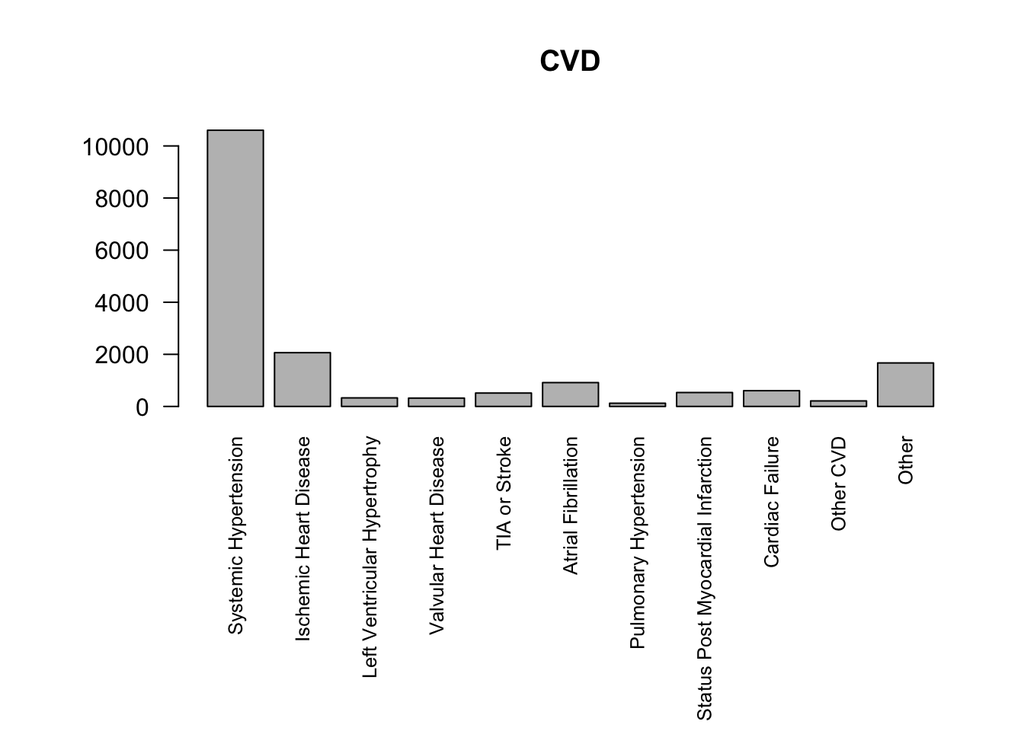

```r
CVD <- c(10602, 2064, 328, 320, 514, 915, 123, 534, 605, 212, 1670)
par(mar=c(11.1,6.1,4.1,2.1))
barplot(CVD, names.arg=c("Systemic Hypertension", "Ischemic Heart Disease", "Left Ventricular Hypertrophy", "Valvular Heart Disease", "TIA or Stroke", "Atrial Fibrillation", "Pulmonary Hypertension", "Status Post Myocardial Infarction", "Cardiac Failure", "Other CVD", "Other"), cex.names = 0.8, ylim= c(0,11000), las=2, main="CVD")
```

#### Variable names to ICD10 codes

Systemic Hypertension = Essential (primary) hypertension = **I10**

Ischemic Heart Disease = Chronic ischemic heart disease = **I25**

Left Ventricular Hypertrophy=Cardiomegaly = **I51.7** (**I51**, Complications and ill-defined descriptions of heart diseae)

Valvular Heart Disease = Nonrheumatic aortic valve disorder, unspecified = **I35.9** (**I35** = Nonrheumatic aortic valve disorders)

TIA or Stroke = Transient cerebral ischemic attack, unspecified = **G45.9** AND/OR Cerebral infarction, unspecified = **I63.9** (**I63** = Cerebral infarction)

Atrial Fibrillation = Unspecified atrial fibrillation = **I48.91** (**I48** = Atrial fibrillation and flutter)

Pulmonary Hypertension = Pulmonary hypertension, unspecified = **I27.20** (**I27** = Other pulmonary heart diseases)

Status Post Myocardial Infarction = Other current complications following acute myocardial infarction = **I23.8** (**I23** = Certain current complications following acute myocardial infarction)

Cardiac Failure = Heart Failure = **I50**

##### Looking at the CVOther (free text)

```r
unique(names(which(sapply(Data2$CVOther, function(x) any(!is.na(x))))))
```

```r
unique(grep("^ar", Data2$CVOther, value=T, ignore.case=T))
```

```
##  [1] "arrhytmua"
##  [2] "arrhytmia"
##  [3] "arrhytmogenic kardiomyopathy"
##  [4] "Arrhytmia"
##  [5] "Arrhytmia unspecified"
##  [6] "Arrhytmia unspecified, pacemaker 9/2017"
##  [7] "Arrhytmia unspec."
##  [8] "Arytmie"
##  [9] "ARYTMIE"
## [10] "arrythmia"
## [11] "Arrhythmia"
## [12] "arrhythmia"
## [13] "arythmia"
## [14] "Arrythmia"
## [15] "ARYTHMIES"
```

[output cut: 60 more lines]

##### The goal is to unify all free text containing the word “arrhythmia” in any possible spelling.

Then the ICD-10 code **I49.9** “Cardiac arrhythmia, unspecified” can be assigned (**I49** Other cardiac arrhythmias)

```r
Data2$CVOther <- gsub("arrhytmua|arrhytmia|arrhytmogenic kardiomyopathy|Arrhytmia|Arrhytmia unspecified|Arrhytmia unspec.|Arytmie|ARYTMIE|arrythmia|Arrhythmia|ARYTHMIES|arythmia|Arrythmia|arythmie|
ARYTHMIA|ARYTHMIA|arritmias|arytmia|arrhythmias|Arytmia|Aryithmia|Arythmia|Arrytmia|Arytmi|arrythmy|arrythmic disease|arrithmya|arryhmia|Arrithmya|arrithmia|heart arrhythmia|heart rhythm disorder|cardiac arrhythmia|cardiac arythmitic|rythme disorder|rythm disorder|rythme disorder|heart ryhtm disorder|^heart arrhythmia$|hEART ARYTMIA|tachy-brady arrhythmia|Cardiac dysrhythmia|atrie arrytmia|Heathrythm disturbance|atythmia|absolute[[:blank:]]arrhythmia|Heart Arritmia|
Cardiac arrhythmias|s/p[[:blank:]]arrhythmia|irregular heartbeat|sometimes arrhythmia|Cardiac arrhythmia|\\<arrhythias\\>|Supraventricular arrhythmia|cardiac dysrhythmia|
disorder of cardiac rythm|heart rhythm disturbance|HEART INACCURACY","arrhythmia",Data2$CVOther)
```

##### The same for “atrial fibrillation” in any possible spelling.

ICD-10 code **I48.91** “Unspecified atrial fibrillation” (**I48** = Atrial fibrillation and flutter)

```r
Data2$CVOther <- gsub("^chronic  atrial fibrilation$|^paroxysmal fibrilation$|^Atrial fibrilation$|^atrial fibrilation$| ^atrial fibrilation paroxysmal$|^Persistent atrial fibrilation$|^Persisting atrial fibrilation$|^Atrial fibrilation permanent$|^Paroxysmal atrial fibrilation$|^paroxsysmal atrial fibrillation$|^Atrial Fibrillation$|^atria Fibrillation$|^arial fibrillation$|^atrial fibrilloflutter$|^atrial fibrillation and flutter$|^paroxysmal atrial fibrillation$|^atrial fibrilation paroxysmal$|^chronic atrial fibrillation$|^FA, not chronic$|^chronic atrial fibriclation$|^atrial fifralation$|^Atrial fibrillation$|^Fibrillatio atriorum$|^non-chronic atrial fibrillation$|^Auricular Fibrilhation$|^PAROSSISTIC ATRIAL FIBRILLATION$|^Atrial fibrillation -paroxysmal$|^artrial fibrialtion$|^arterial fibrilation$|^atrila fibrillation$|^atrial fibrillation paroxysmal$|^artrial fibrillation$|^Intermittent Atrial fibrillation$|^Paroxysmal Atrial fibrillation$|^Paroxystisk AF$|^fibrillatio atriorum$|^fibryllatio atriorum$|^Fibryllatio atriorum$|^Intermittent atrial fibrillation night timei$|^atrial fibrylation$|^atrial fibration$|^Fibrillatio atriorum$|^atrial fibrilliation$|^intermittent atrial fibrillation$|^atrial fibrilhation$|^artial fibrillation$|^Atrial fibrilation$|^Atrial fibrillation$|^Atrial Fibrilation$|^ATRIAL FIBRILLATION$|^a-fib$|^paroxysmal atrial fibrillation$|^paroxysmal a-fib$|^A-FIB$|^Paroxysmal Atrial Fibrillation$|^parox. a fib$|^paroxysmal atrial fib$|^atrial fib$|^Atrial fibrilation$|^atrial fibrilation$|^Intermittent fibrillation$|^a fib$|^A fib$|^Atrial fibrilation$|^Atrial fibrillation$|^Patrial fibrillation$|^atrieflimme$|^Atrieflimmer$|^atrieflimmer$|^chr. flimmer$|^paroxymal flimmer$|^paroks. atrial fibrallation$|^parogsymal flimmer$|^paroksymal flimmer$|^Fibrillatio atriorum$|^Atrial fibrillation,$|^atrial fibrallation$|^paroxysmal atrial fibrillation$|^parossitic FA$|^paroxysmal atrium fibriliation$|^Paroxysmal atrial fibrillation$|^flimmeri$|^Persister.atrieflimmer$|^ flimmeri$^Persisting atrial fibrilation, st.p.ECV 5/2017$|^atrial fibrallation: pacemaker$|^ACFA$|^atrieflimmer,opr aortainsuff$|^Persistent atrial fibrilation, Pacemaker 2017$|^AF,flutter, trombe i u.ex$", "atrial fibrillation", Data2$CVOther)
```

ICD-10 code **I48.92** “Unspecified atrial flutter” (**I48** = Atrial fibrillation and flutter)

```r
Data2$CVOther <- gsub("^atrial flutter-paroxysmal$|^atrial fibrilloflutter$|^Atrial flutter$|^Paroxysmal Atrial Flutter,$|^atrial flutter-paroxysmal,$|^Atrial flutter Pacemaker$|^Atrial flutter 2:1$","atrial flutter", Data2$CVOther)
```

ICD-10 code **Z95.0** “Presence of cardiac pacemaker”

```r
Data2$CVOther <- gsub("^pacemaker$|^paacemaker$|^PACEMAKER$|^Pcemaker$|^Pacemaker$|^PM due to sick sinus$|^Pacemaker due to bradycardia$|^pace maker$|^pacemaker for heartblock$|^pace maker, a-fib$|^Pacemaker since 1986$|^PACEMAKER,ANEURYSM$|^Pacemaker 2017$|^cardiac pacemaker$|^treated by cardiac PM$|^pace-maker implanted$|^pacemaker 9/2017$|pace-maker|Pacemaker 05/2016$","pacemaker", Data2$CVOther)
```

ICD-10 code **R00.0** “Tachycardia, unspecified”

```r
Data2$CVOther <- gsub("^Tachycardie$|^Tachycardia$|^Tachykardi$|^Taquicardia$|^Takykardia$|^takykardia$|^sinus tachycardia$|^Sinus tachycardia$","tachycardia unspecified", Data2$CVOther)
```

ICD-10 code **R00.1** “Bradycardia, unspecified”

```r
Data2$CVOther <- gsub("^sinus bradykardia$|^Bradycardia$|^Nocturnal Bradycardia$|^sinus bradycardia$","bradykardia", Data2$CVOther)
```

ICD-10 code **R00.2** “Palpitations”

```r
Data2$CVOther <- gsub("^Palpitations$|^Palpatations$|^Intermittent palpitation$","palpitations", Data2$CVOther)
```

ICD-10 code **R22.4** “Localized swelling, mass and lump, unspecified lower limb”

```r
Data2$CVOther <- gsub("^Leg swelling$|^Leg oedema$","leg swelling", Data2$CVOther)
```

ICD-10 code **I73.9** “Peripheral vascular disease, unspecified”

```r
Data2$CVOther <- gsub("^PVD$|^Peripheral Vascular disease$|^Peripheral vascular disease$|^Peripheral Vascular Disease$|^peripheral arterial occlusion disease$|^peripheral arterial disease$|^Peripheral arterial disease$|^Peripheral arterial dissease$|^peripheral artery disease$|^Limb ischemia$|^Limb ischemia$|^aorto bifemoral bypass$|ARTHERIOPAHIE|ARTERIOPATHIE|^PTCA A. femoralis$|^A. femoralis thrombosis$|^atherosclerosis of the legs$","peripheral vascular disease", Data2$CVOther)
```

ICD-10 code **Z86.71** “Personal history of venous thrombosis and embolism”

```r
Data2$CVOther <- gsub("^P.E$|^pulmonary thromboembolism$|^pulmonal emboli$|^Pulm emboli$|^Pulmonary embolus$|^Pulmonary embolism$|^pulmonary embolus$|^Pulmonary embolus$|^pulmonary embolism 2008$|^deep venous trombosis, trombophilia$|^Deep vein trombosis recidiving$|deep[[:blank:]]venous[[:blank:]]trombosis|^Deep vein thrombosis$|^Thromboembolism$|^St.p.flebotrombosis 2016$|^DEEP VEIN THROMBOSIS$|^DVT$|^DVT 2013$|^status post flebothrombosis$|^deep venous trombosis$|S.p.lung embolia[[:blank:]]2014|^St.p.DVT 2011$|^trombosis dk$|^status post phlebothrombosis of the lower limbs$|^St.p. trombosis of left lower limb$|^st.p. pulmonary embolism$|^St.p.DVT 2013$|^St.p. lung embolism 2013 from FP trombosis$|postrombotic[[:blank:]]syndrom|posttrombotic[[:blank:]]syndrom|^St.p. lung embolism 1983$|^St.p.PE 2014, St.p.flebotrombosis$|^vein thrombosis$|^Thrombosis$|^embolia arteriae pulmonalis$|^pulmonary embolism in 2007. I degree AV block$|^St.p. lung embolism 1999, 2004$|^Post VT$|^Venous thrombosis$|^thrombosis$|^pulmonary embolism$","pe-dvt", Data2$CVOther)
```

ICD-10 code **I45.10** “Unspecified right bundle-branch block”

```r
Data2$CVOther <- gsub("^RBBB, AVB I.$|^RBBB$|^iRBBB$|^AV block I.degree, iRBBB$|^RBBB, sinus bradycardia$|^iRBBB, AVB I.$","RBBB", Data2$CVOther)
```

ICD-10 code **I44.7** “Left bundle-branch block, unspecified”

```r
Data2$CVOther <- gsub("^LBBB, iRBBB$|^LBBB,St.p.myokarditis 2008$","LBBB", Data2$CVOther)
```

ICD-10 code **I47.0** “Re-entry ventricular arrhythmia” (**I47** = Paroxysmal tachycardia)

```r
Data2$CVOther <- gsub("^re-entry tachycardia$","re-entry ventricular tachycardia", Data2$CVOther)
```

ICD-10 code **I47.1** “Supraventricular tachycardia” (**I47** = Paroxysmal tachycardia)

```r
Data2$CVOther <- gsub("^supra ventricular tachycardia$|^Supraventricular arrhythmia$|^Paroxysmal atriventricular tachycardia$|SVES+VES|SVES|VES|SVES/VES","supraventricular tachycardia",Data2$CVOther)
```

ICD-10 code **I47.2** “Ventricular tachycardia” (**I47** = Paroxysmal tachycardia)

```r
Data2$CVOther <- gsub("^Ventricular tachycardia$|^paroxsystisk ventrikulær takykardi$|^Tidl.rytmeforstyrrelse$","ventricular tachycardia", Data2$CVOther)
```

ICD-10 code **I47.9** “Paroxysmal tachycardia, unspecified” (**I47** = Paroxysmal tachycardia)

```r
Data2$CVOther <- gsub("^tachycardia of bouveret$|^Bouverte syndrome$|^periodic tachy$|^Tachycardia intermittent$","paroxysmal tachycardia", Data2$CVOther)
```

ICD-10 code **I49.3** “Ventricular premature depolarization (**I49** = Other cardiac arrhythmias)

```r
Data2$CVOther <- gsub("Ventricular[[:blank:]]extrasystolia|^exstrasystolia$|^extra systolia$|ventricular[[:blank:]]extrasystolia|^Ekstra systoler$|^ekstrasystoler$|^ekstrasystoles$|isol.ventricular[[:blank:]]extrasystoles|^ventricular extrasystolia$","ventricular premature depolarization", Data2$CVOther)
```

ICD-10 code **I49.5** “Sick sinus syndrome” (**I49** = Other cardiac arrhythmias)

```r
Data2$CVOther <- gsub("^tachy-brady arrhytmia$|^tachycardia-bradycardia syndrome$|Sick[[:blank:]]sinus[[:blank:]]syndrom|tachycardia-bradycardia syndrome[[:blank:]]-[[:blank:]]VVI$|^Sick Sinus syndrome$","sick sinus syndrome", Data2$CVOther)
```

ICD-10 code **I44.0** “Atrioventricular block, first degree”

```r
Data2$CVOther <- gsub("AVB[[:blank:]]I.degree$|^Type[[:blank:]]1[[:blank:]]AV[[:blank:]]block|AVB[[:blank:]]I.|AVBlock[[:blank:]]I.degree|AV[[:blank:]]block[[:blank:]]I.degree|I[[:blank:]]degr.[[:blank:]]A-V[[:blank:]]block|I[[:blank:]]degreevAV[[:blank:]]block","AV block I", Data2$CVOther)
```

ICD-10 code **I44.1** “Atrioventricular block, second degree”

```r
Data2$CVOther <- gsub("^AVB II.degree$|^AVB II.degree$|^AVB II Wenkebach$|nocturnal AV[[:blank:]]2nd[[:blank:]]degree[[:blank:]]blocks|^II grade AV. block:pacemaker$|^AV block 2 , pacemaker$|AV[[:blank:]]blockade[[:blank:]]of[[:blank:]]1st[[:blank:]]and[[:blank:]]2nd[[:blank:]]degree$","AV block II", Data2$CVOther)
```

ICD-10 code **I44.2** “Atrioventricular block, complete”

```r
Data2$CVOther <- gsub("^AVB III.degree$|^AVB III$|^AV-block III degener$|^III degree AV block$|AV[[:blank:]block[[:blank:]]3|AV blocks III$|AV-block[[:blank:]]3[[:blank:]]+PM|^AVB III, impl.PM 2018$","AV block III", Data2$CVOther)
```

ICD-10 code **I44.3** “Unspecified atrioventricular block”

```r
Data2$CVOther <- gsub("^AVB unspec.$|^AV block$|AV-block","AV block unspecified", Data2$CVOther)
```

ICD-10 code **I83.2** “Varicose veins of unspecified lower extremity with both ulcer and inflammation”

```r
Data2$CVOther <- gsub("^Leg varices$|^Venous leg ulcers$|Leg[[:blank:]]varices[[:blank:]]and [[:blank:]]ulcers|Venous[[:blank:]]ulceration|Venous[[:blank:]]ulcers|Varices[[:blank:]]cruris [[:blank:]]bilat.|Varices[[:blank:]]cruris|^varices cruris$|^aricose veins bilat$|varices|^varicose vein$|^varices surgery$|^varices cruris surgery$|^varicose vein surgery$|^varices operation$|^varices,varicose ulcer$|^Leg varicose veins$|^Leg varicose veins and ulcers$|^leg varicose veins$|^varicous veins$","varicose veins", Data2$CVOther)
```

ICD-10 code **I87.2** “Venous insufficiency (chronic) (peripheral)”

```r
Data2$CVOther <- gsub("Chronic[[:blank:]]vein[[:blank:]]insuficiency|^chronic venous insuffitienci$|^chronic venous isufficienci$|^chronic venous insuficienci$|^chronic venous insuficiency of the lower limbs$|^chronic venous insuficiency of lower limbs$|^chronic venous insufficiency of the lower limbs$|^chronic venous insufficiency,$|^chronic venous insufficiency$|^venous disease,$","venous insufficiency", Data2$CVOther)
```

ICD-10 code **I80.3** “Phlebitis and thrombophlebitis of lower extremities, unspecified”

```r
Data2$CVOther <- gsub("^Vaskulitis$|^venous disease of the lower limbs$|^Recid.flebotrombosis$|^phlebitis$|phlebothrombosis|^Phlebitis$|^St.p.flebotrombosis$|^Plhlebite$|St.p.tromboflbitis[[:blank:]]LL|^phlebotrombosis of left limb$|^phlebite$|^flebotromboza$","thrombophlebitis", Data2$CVOther)
```

ICD-10 code **Q21.1** “Atrial septal defect” (Persisting foramen ovale)

```r
Data2$CVOther <- gsub("^Persisting foramen ovale$|^open foramen ovale$|^Open foramen ovale$|^persistent foramen ovale$|^ASD II$|^Persistent foramen ovale$","atrial septal defect", Data2$CVOther)
```

ICD-10 code **I45.6** “Pre-excitation syndrome”

```r
Data2$CVOther <- gsub("^WPW-SDR$|^Wolff-Parkinson-White syndrome$|^Wolff-Parkinson-White$|^WPW syndrome$|^Wolf parkingson white$","pre-excitation syndrome", Data2$CVOther)
```

ICD-10 code **I71.00** “Dissection of unspecified site of aorta”

```r
Data2$CVOther <- gsub("^aortal dissection type B$|^Aortic Dissection type B$|^Ruptured aneurysm$|^Aortic dissection$|^aortic dissection$|^AORTIC DISSECTION$|^surgically treated aorta aneurysm$|^aorta dissection$|^Aorta dissection/rupture$|^dissection$|^Aortadissection 2012$","dissection of aorta unspecified", Data2$CVOther)
```

ICD-10 code **I71.2** Thoracic aortic aneurysm, without rupture

```r
Data2$CVOther <- gsub("^Ascendent aortic aneurysm$|^ANEURYSM OF ASCENDING AORTA$|^ANEURYSM OF THRACIC AORTA$","thoracic aortic aneurysm", Data2$CVOther)
```

ICD-10 code **I71.4** “Abdominal aortic aneurysm, without rupture”

```r
Data2$CVOther <- gsub("^abdominal aortic aneurysm$|^aneurysm of the abdominal aorta$|^Descending aorta$","abdominal aortic aneurysm", Data2$CVOther)
```

ICD-10 code **I71.9** “Aortic aneurysm of unspecified site, without rupture”

```r
Data2$CVOther <- gsub("^aortic aneurism$|^Anévrysme of the aorta$|^aneurism$|^Aorta aneurysm$|^Aortic aneurysm$|^aorta-aneurysm$","aortic aneurysm unspecified", Data2$CVOther)
```

ICD-10 code **I51.9** “Heart disease, unspecified”

```r
Data2$CVOther <- gsub("^Heart disease$|^heart disease$|^Heart problems$|^heart oroblems$|heart Poroblems$|^heart problems$|^cardiac disease$|^HEART PROBLEMS$|^Heartb disease$","heart disease", Data2$CVOther)
```

ICD-10 code **I42.9** “Cardiomyopathy, unspecified”

```r
Data2$CVOther <- gsub("^Kardiomyopati$|^cardiomyopati$|^cardiomiopatia$","cardiomyopathy unspecified", Data2$CVOther)
```

```r
Data2$CVOther <- gsub("^dilated cardiomyopathy$|^left atrial dillatation$|^Dilatert kardiomyopati$|^Dilated cardiomyopathy$","cardiomyopathy unspecified", Data2$CVOther)
```

ICD-10 code **I42.2** “Other hypertrophic cardiomyopathy”

```r
Data2$CVOther <- gsub("^Hypertrophic myocardiopati$|^hypertrophic cardiomyopathy$|^heart muscle hypertrophy$","hypertrophic cardiomyopathy", Data2$CVOther)
```

ICD-10 code **I51.81** “Takotsubo syndrome”

```r
Data2$CVOther <- gsub("^Takotsubo cardiomyopathy$|^Takotsubocardiomyopati$","takotsubo syndrome", Data2$CVOther)
```

ICD-10 code **I11.9** “Hypertensive heart disease without heart failure”

```r
Data2$CVOther <- gsub("hypertensive cardiomyopath", "hypertensive heart disease", Data2$CVOther)
```

ICD-10 code **I25.1** “Atherosclerotic heart disease of native coronary artery”

```r
Data2$CVOther <- gsub("^CABG$|^Coronary Artery Bypass Graft$|^bypass$|triple bypass|^coronary artery bypass$|^Coronary bypass$|^coronary bypass$|^coronary stents$|^bypass surgery$|^coronary artery bypass graft$|^By pass surgery-74$|^By pass surgery$|^Aorta by pass surgery$|^Bypass surgery 2007$|^Op bypass$|^coronary stents$|^ACB surgery$|^ACB surgery 2010$|^stent opr$|^Coronar stent$|^stenting, coronary artery bypass graft$|^CABG, stenting$|^stenting$|^coronair stenose$|^INSUFISANCE CARDIAQUE AND CORONAIRE$|^INSUFFISANCE CORONAIRE$|^Coronopathie$|^coronary heart disease$|^atherosclerotic coronary disease$|^coronary failure$|^stunt-opr.$|^coronary insufficiency$|^cardio artery stenosis$|^coronary heartdisease$|^PCI$|^PTCA$|^ACB + stent opr$|^St.p.2xCABG$|^St.p.2xCABG 2014$|^Coronary artey desease surgery$", "coronary artery disease", Data2$CVOther)
```

- This code also includes coronary artery bypass graft (CABG), coronary stents

ICD-10 code **I27.81** “Cor pulmonale (chronic)”

```r
Data2$CVOther <- gsub("^Cor pulmonale$","cor pulmonale", Data2$CVOther)
```

ICD-10 code **Z86.79** “Personal history of other diseases of the circulatory system”

```r
Data2$CVOther <- gsub("^ablation$|^st.p.catether ablation, unspecified$|^AVNRT, st.p. RF ablation$|^st.p.RF ablation$","other circulatory", Data2$CVOther)
```

ICD-10 code **R01.1** “Cardiac murmur, unspecified”

```r
Data2$CVOther <- gsub("^murmur$|^murmer$|^Systolic murmur$|^Holosystolic murmur$","cardiac murmur", Data2$CVOther)
```

ICD-10 code **I73.0** “Raynaud’s syndrome”

```r
Data2$CVOther <- gsub("^Raynaud disease$","Raynaud", Data2$CVOther)
```

ICD-10 code **I70.219** “Atherosclerosis of native arteries of extremities with intermittent claudication, unspecified extremity”

```r
Data2$CVOther <- gsub("^Claudicatio$|^Intermittent claudication$","intermittent claudication", Data2$CVOther)
```

ICD-10 code **K64.9** “Unspecified hemorrhoids”

```r
Data2$CVOther <- gsub("^Hemorrhoides$|^Haemmorhoids$|^Haemorrhoides$|^hemorrhoids$","hemorrhoids", Data2$CVOther)
```

ICD-10 code **I20.9** “Angina pectoris, unspecified”

```r
Data2$CVOther <- gsub("^Angina pectoris$|^Angina Pectoris$|^angina pectoris stabilis$|^Angina ,utredast$|^Angina?$","angina unspecified", Data2$CVOther)
```

ICD-10 code **I20.0** “Instable Angina pectoris”

```r
Data2$CVOther <- gsub("^Unstable angina$","instable angina", Data2$CVOther)
```

ICD-10 code **R55** “Syncope and collapse”

```r
Data2$CVOther <- gsub("^vasovagal syndrome$","syncope", Data2$CVOther)
```

ICD-10 code **Z95.810** “Presence of automatic (implantable) cardiac defibrillator”

```r
Data2$CVOther <- gsub("^ICD$|^ICD from 2011$|^DEFIBRILLATOR$|^kardioverter defibrillator$|^ICD-CRT-D 7/2016$","defibrillator", Data2$CVOther)
```

##### Further cleaning done manually, ICD-10 codes assigned to CVOther

```r
CV_ICD10 <- read.csv("CVOther_ICD10.csv", header=TRUE, sep=",")
str(CV_ICD10)
```

```
## 'data.frame':    25499 obs. of  1 variable:
##  $ CVOther_ICD10: Factor w/ 178 levels " Z95.5","025S0ZZ ",..: NA NA NA NA NA NA NA 127 NA NA ...
```

##### MetabolicOther

unique(names(which(sapply(Data2$MetabolicOther, function(x) any(!is.na(x)))))) N=604

##### PulmonaryOther

unique(names(which(sapply(Data2$PulmonaryOther, function(x) any(!is.na(x)))))) N=457

##### SleepDisorderOther

unique(names(which(sapply(Data2$SleepDisorderOther, function(x) any(!is.na(x)))))) N=373

##### Other

unique(names(which(sapply(Data2$Other, function(x) any(!is.na(x)))))) N=2561